# AGDS Report 2 - digital soil mapping

Nora Bisang

2025-12-23

## 1. Introduction

This report investigates the spatial prediction of soil waterlogging at 100 cm depth using digital soil mapping techniques. Random Forests are trained on field observations and environmental covariates, with predictor selection using Boruta, followed by an optional hyperparameter tuning. Model performance is evaluated on an independent validation dataset and results are spatially upscaled to the study area.

## 2. Setup and data acquisition

### 2.1 Setup and raw data

```r
library(here)
library(dplyr)
library(readr)
library(purrr)
library(ggplot2)
library(terra)
library(tidyterra)
library(sf)
library(leaflet)
library(knitr)
library(ranger)
library(stringr)
library(caret)
library(Boruta)
library(pROC)
```

Loading dataset containing soil observations and site metadata used for model calibration and validation.

```r
df_full <- readRDS(here("data-raw", "df_full.rds"))
```

```r
df_obs <- readr::read_csv(
  here::here("data-raw/soildata/berne_soil_sampling_locations.csv")
  )

# Display data
head(df_obs) |>
  knitr::kable()
```

| site_id_unique | timeset | x | y | dataset | dclass | waterlog.30 | waterlog.50 | waterlog.100 | ph.0.10 | ph.10.30 | ph.30.50 | ph.50.100 |
| --- | --- | --- | --- | --- | --- | --- | --- | --- | --- | --- | --- | --- |
| 4_26-In-005 | d1968_1974_ptf | 2571994 | 1203001 | validation | poor | 0 | 0 | 1 | 6.071733 | 6.227780 | 7.109235 | 7.214589 |
| 4_26-In-006 | d1974_1978 | 2572149 | 1202965 | calibration | poor | 0 | 1 | 1 | 6.900000 | 6.947128 | 7.203502 | 7.700000 |
| 4_26-In-012 | d1974_1978 | 2572937 | 1203693 | calibration | moderate | 0 | 1 | 1 | 6.200000 | 6.147128 | 5.603502 | 5.904355 |
| 4_26-In-014 | d1974_1978 | 2573374 | 1203710 | validation | well | 0 | 0 | 0 | 6.600000 | 6.754607 | 7.200000 | 7.151129 |
| 4_26-In-015 | d1968_1974_ptf | 2573553 | 1203935 | validation | moderate | 0 | 0 | 1 | 6.272715 | 6.272715 | 6.718392 | 7.269008 |
| 4_26-In-016 | d1968_1974_ptf | 2573310 | 1204328 | calibration | poor | 0 | 0 | 1 | 6.272715 | 6.160700 | 5.559031 | 5.161655 |

### 2.2 Covariate Raster “Inventar”

```r
# Get a list with the path to all raster files
list_raster <- list.files(
  here::here("data-raw/geodata/covariates/"),
  full.names = TRUE
)
```

### 2.3 Sampling locations

This map shows the spatial distribution of calibration and validation sites in the study area. A larger base map is used to provide geographic context.

[interactive chart not shown]

## 3. Covariate preparation

### 3.1 Raster stacking

Reduction of rasters to the x and y coordinates for which we have soil sampling data. All covariate rasters and sampling coordinates are provided in the Swiss coordinate reference system (CH1903+ / LV95, EPSG:2056), allowing direct extraction of raster values at sampling locations.

```r
# Stack all environmental covariates into a single raster
all_rasters <- rast(list_raster)

# Extract coordinates from sampling locations
sampling_xy <- df_obs |>
  dplyr::select(x, y)
```

### 3.2 Extraction at sampling locations

Merging of of soil data and covariates data by their coordinates.

```r
# From all rasters, extract values for sampling coordinates
df_covars <- terra::extract(
  all_rasters,
  sampling_xy,
  ID = FALSE
  )

df_full <- cbind(df_obs, df_covars)
```

### 3.3 Detection categroical variables

Variables with 10 or less different values are treated as categorical, assuming they represent classes rather than continuous gradients.

```r
vars_categorical <- df_covars |>
  summarise(across(everything(), ~ n_distinct(.))) |>
  tidyr::pivot_longer(
    everything(),
    names_to = "variable",
    values_to = "n"
  ) |>
  filter(n <= 10) |>
  pull("variable")

cat(
  "Variables with less than 10 distinct values:",
  ifelse(length(vars_categorical) == 0, "none", vars_categorical)
)
```

```
## Variables with less than 10 distinct values: geo500h1id
```

Mutate categorical columns in our data frame

```r
df_full <- df_full |>
  dplyr::mutate(dplyr::across(all_of(vars_categorical), ~as.factor(.)))
```

### 3.4 Missing Data

Missing data is examined by computing the percentage of non-missing observations for each predictor variable. For subsequent analysis dataset can be used without removal of variable, as the proportion of missing values is low.

```r
n_rows <- nrow(df_full)

# number of distinct values per variable
df_full |>
  summarise(across(
    everything(),
    ~ length(.) - sum(is.na(.))
  )) |>
  tidyr::pivot_longer(everything(),
    names_to = "variable",
    values_to = "n"
  ) |>
  mutate(perc_available = round(n / n_rows * 100)) |>
  arrange(perc_available) |>
  head(10) |>
  knitr::kable()
```

| variable | n | perc_available |
| --- | --- | --- |
| ph.30.50 | 856 | 81 |
| ph.10.30 | 866 | 82 |
| ph.50.100 | 859 | 82 |
| timeset | 871 | 83 |
| ph.0.10 | 870 | 83 |
| dclass | 1006 | 96 |
| site_id_unique | 1052 | 100 |
| x | 1052 | 100 |
| y | 1052 | 100 |
| dataset | 1052 | 100 |

### 3.5 Saving of processed data

```r
if (!dir.exists(here::here("data"))) system(paste0("mkdir ", here::here("data")))
saveRDS(df_full,
        here::here("data/df_full.rds"))
```

## 4. Model training

### 4.1 Target definition

```r
target <- "waterlog.100"
```

### 4.2 Predictor definition

```r
# Specify predictors_all: Remove soil sampling and observational data
predictors_all <- names(df_full)[14:ncol(df_full)]

cat("The target is:", target,
    "\nThe predictors_all are:", paste0(predictors_all[1:8], sep = ", "), "...")
```

```
## The target is: waterlog.100
## The predictors_all are: be_gwn25_hdist,  be_gwn25_vdist,  cindx10_25,  cindx50_25,  geo500h1id,  geo500h3id,  lgm,  lsf,  ...
```

### 4.3 Splitting dataset train/ test

Splitting of the dataset into calibration and validation subsets (based on present labels) to ensure spatial independence for evaluation.

```r
# Split dataset into training and testing sets
df_train <- df_full |> filter(dataset == "calibration")
df_test  <- df_full |> filter(dataset == "validation")

# Filter out any NA to avoid error when running a Random Forest
df_train <- df_train |>  drop_na()

df_test <- df_test |>    drop_na()

# A little bit of verbose output:
n_tot <- nrow(df_train) + nrow(df_test)

perc_cal <- (nrow(df_train) / n_tot) |> round(2) * 100
perc_val <- (nrow(df_test)  / n_tot) |> round(2) * 100

cat("For model training, we have a calibration / validation split of: ",
    perc_cal, "/", perc_val, "%")
```

```
## For model training, we have a calibration / validation split of:  75 / 25 %
```

### 4.4 Exercise 1 – Class balance

```r
table(df_train$waterlog.100)
```

```
##
##   0   1
## 358 247
```

```r
prop.table(table(df_train$waterlog.100))
```

```
##
##         0         1
## 0.5917355 0.4082645
```

Interpretation of Class Balance

The training dataset shows moderate class imbalance. From 605 observations, 358 (59.2 %) are in the not-waterlogged class, while 247 observations (40.8 %) are in the waterlogged class.

This imbalance is not severe and both classes are still well represented. Therefore class weighting will notbe applied during model training.

However, as predicting only the majority class “not-waterlogged” would already achieve an accuracy of 59 %, accuracy alone is not a sufficient performance metric. This is why the model evaluation will focus not only on accuracy, but also on sensitivity, specificity, precision, balanced accuracy, and AUC, which are more informative under class imbalance.

## 4.5 Random Forest basic model

Model training with default hyperparameters used by ranger::ranger().

```r
rf_basic <- ranger(
  y = df_train[, target],
  x = df_train[, predictors_all],
   classification = TRUE,
  importance = "permutation",
  seed = 42,
  num.threads = parallel::detectCores() - 1,
)

# Print a summary of fitted model
print(rf_basic)
```

```
## Ranger result
##
## Call:
##  ranger(y = df_train[, target], x = df_train[, predictors_all],      classification = TRUE, importance = "permutation", seed = 42,      num.threads = parallel::detectCores() - 1, )
##
## Type:                             Classification
## Number of trees:                  500
## Sample size:                      605
## Number of independent variables:  91
## Mtry:                             9
## Target node size:                 1
## Variable importance mode:         permutation
## Splitrule:                        gini
## OOB prediction error:             21.49 %
```

## 5. Variable selection using Boruta

The number of variables will be reduced to avoid collinearity and the risk of overfitting.

### 5.1 Extraction of Variable importance

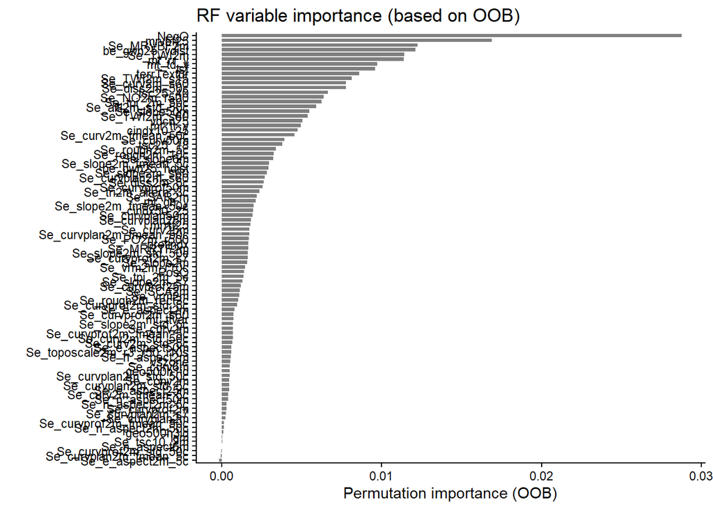

```r
# Extraction the variable importance
vi_rf_basic <- rf_basic$variable.importance |>
  bind_rows() |>
  pivot_longer(cols = everything(), names_to = "variable")


# Plot variable importance, ordered by decreasing value
gg <- vi_rf_basic |>
  ggplot(aes(x = reorder(variable, value), y = value)) +
  geom_bar(stat = "identity", fill = "grey50", width = 0.75) +
  labs(
    y = "Permutation importance (OOB)",
    x = "",
    title = "RF variable importance (based on OOB)"
  ) +
  theme_classic() +
  coord_flip()

# Display plot
gg
```

### 5.2 Variable Selection

Note that this algorithms does not assess all possible combinations of predictors_all and may thus not find the “globally” optimal model.

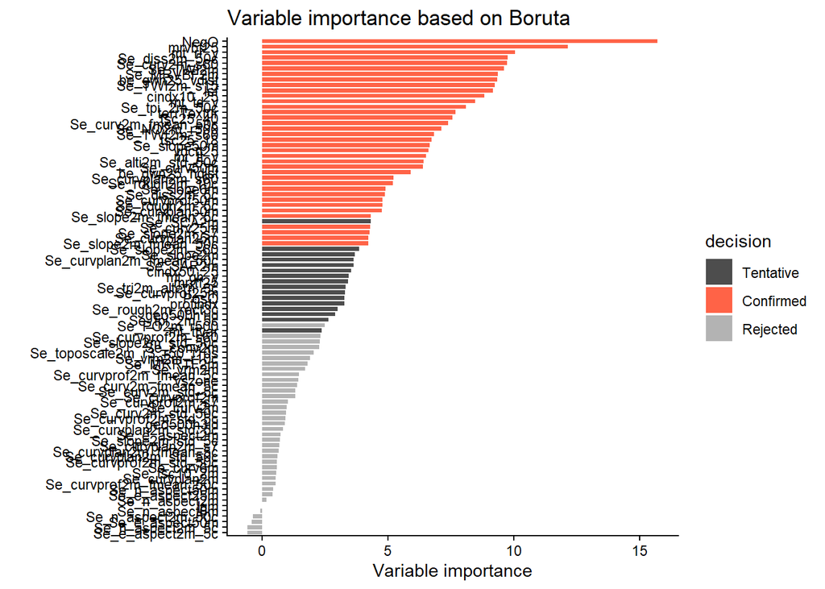

```r
#install.packages("Boruta")
library(Boruta)
set.seed(42)


# run the algorithm
bor <- Boruta::Boruta(
    y = df_train[, target],
    x = df_train[, predictors_all],
    maxRuns = 50, # Set to 30 or lower if it takes too long
    num.threads = parallel::detectCores()-1)


df_bor <- Boruta::attStats(bor) |>
  tibble::rownames_to_column() |>
  dplyr::arrange(dplyr::desc(meanImp))

# plot the importance result
ggplot2::ggplot(ggplot2::aes(x = reorder(rowname, meanImp),
                             y = meanImp,
                             fill = decision),
                data = df_bor) +
  ggplot2::geom_bar(stat = "identity", width = 0.75) +
  ggplot2::scale_fill_manual(values = c("grey30", "tomato", "grey70")) +
  ggplot2::labs(
    y = "Variable importance",
    x = "",
    title = "Variable importance based on Boruta") +
  ggplot2::theme_classic() +
  ggplot2::coord_flip()
```

### 5.3 Retiring Confirmed variable

```r
# get retained important variables
predictors_selected <- df_bor |>
  filter(decision == "Confirmed") |>
  pull(rowname)

length(predictors_selected)
```

```
## [1] 37
```

### 5.4 Retraining RF

Retraining random forest with only the “Confirmed” predictor variables

```r
rf_bor <- ranger(
  y = df_train[, target],
  x = df_train[, predictors_selected],
  seed = 42,
  classification= T,
  num.threads = parallel::detectCores() - 1,
  )

# quick report and performance of trained model object
rf_bor
```

```
## Ranger result
##
## Call:
##  ranger(y = df_train[, target], x = df_train[, predictors_selected],      seed = 42, classification = T, num.threads = parallel::detectCores() -          1, )
##
## Type:                             Classification
## Number of trees:                  500
## Sample size:                      605
## Number of independent variables:  37
## Mtry:                             6
## Target node size:                 1
## Variable importance mode:         none
## Splitrule:                        gini
## OOB prediction error:             21.49 %
```

### 5.5 Safe files

```r
saveRDS(rf_basic,
        here::here("data/rf_for_waterlog_100_basic.rds"))
saveRDS(rf_bor,
        here::here("data/rf_for_waterlog_100.rds"))

saveRDS(df_train[, c(target, predictors_all)],
        here::here("data/cal_for_waterlog_100.basic.rds"))
saveRDS(df_test[, c(target, predictors_all)],
        here::here("data/val_for_waterlog_100.basic.rds"))

saveRDS(df_train[, c(target, predictors_selected)],
        here::here("data/cal_for_waterlog_100.rds"))
saveRDS(df_test[, c(target, predictors_selected)],
        here::here("data/val_for_waterlog_100.rds"))
```

## 6. Model Analysis

### Model Comparison - Exercize 2

Compare the skill of the models with all predictors and with the Boruta-informed reduced set of predictors.

### 6.1 Predictions

```r
prediction_bor <- predict(
  rf_bor,
  data = df_test[, predictors_selected],
  num.threads = parallel::detectCores() - 1
)

df_test$pred_boruta_class <- prediction_bor$predictions



prediction_basic <- predict(
  rf_basic,
  data = df_test[, predictors_all],
  num.threads = parallel::detectCores() - 1
)

df_test$pred_basic_class <- prediction_basic$predictions
```

### 6.2 Confusion matrixes

```r
# Convert predictions to factor
df_test$pred_boruta_class <- factor(df_test$pred_boruta_class, levels = c(0, 1))
df_test$pred_basic_class <- factor(df_test$pred_basic_class, levels = c(0, 1))

# Convert target to factor
df_test[[target]] <- factor(df_test[[target]], levels = c(0, 1))

#boruta model
confusion_bor <- confusionMatrix(
  data = df_test$pred_boruta_class,
  reference = df_test[,target],
  positive = "1"
)

confusion_bor
```

```
## Confusion Matrix and Statistics
##
##           Reference
## Prediction   0   1
##          0 107  19
##          1  23  51
##
##                Accuracy : 0.79
##                  95% CI : (0.7269, 0.8443)
##     No Information Rate : 0.65
##     P-Value [Acc > NIR] : 1.134e-05
##
##                   Kappa : 0.5445
##
##  Mcnemar's Test P-Value : 0.6434
##
##             Sensitivity : 0.7286
##             Specificity : 0.8231
##          Pos Pred Value : 0.6892
##          Neg Pred Value : 0.8492
##              Prevalence : 0.3500
##          Detection Rate : 0.2550
##    Detection Prevalence : 0.3700
##       Balanced Accuracy : 0.7758
##
##        'Positive' Class : 1
##
```

```r
#basic model
confusion_basic <- confusionMatrix(
  data = df_test$pred_basic_class,
  reference = df_test[[target]],
  positive = "1"
)

confusion_basic
```

```
## Confusion Matrix and Statistics
##
##           Reference
## Prediction   0   1
##          0 104  22
##          1  26  48
##
##                Accuracy : 0.76
##                  95% CI : (0.6947, 0.8174)
##     No Information Rate : 0.65
##     P-Value [Acc > NIR] : 0.0005292
##
##                   Kappa : 0.4794
##
##  Mcnemar's Test P-Value : 0.6650055
##
##             Sensitivity : 0.6857
##             Specificity : 0.8000
##          Pos Pred Value : 0.6486
##          Neg Pred Value : 0.8254
##              Prevalence : 0.3500
##          Detection Rate : 0.2400
##    Detection Prevalence : 0.3700
##       Balanced Accuracy : 0.7429
##
##        'Positive' Class : 1
##
```

### 6.3 OOB

```r
rf_basic$prediction.error
```

```
## [1] 0.214876
```

```r
rf_bor$prediction.error
```

```
## [1] 0.214876
```

### 6.4 Interpretation

The confusion matrixes show that the predictor reduced model (rf_bor) consistently outperforms the basic model (rf_basic) across all shown metrics.

The outperformance of the reduced predicot model is indication that predictor selection by Boruta was useful to remove noisy and irrelevant predictors, improving the performance on unseen data (generaliseability). Thus the reduced set will be used for further analysis.

## 7. Spatial Upscaling

### 7.1 Mask loading

```r
raster_mask <- rast(here("data-raw/geodata/study_area/area_to_be_mapped.tif"))

# Turn target raster into a dataframe
df_mask <- as.data.frame(raster_mask, xy = TRUE)

df_mask <- df_mask |>
  filter(area_to_be_mapped == 1)

head(df_mask) |>
  kable()
```

| x | y | area_to_be_mapped |
| --- | --- | --- |
| 2587670 | 1219750 | 1 |
| 2587690 | 1219750 | 1 |
| 2587090 | 1219190 | 1 |
| 2587090 | 1219170 | 1 |
| 2587110 | 1219170 | 1 |
| 2587070 | 1219150 | 1 |

### 7.2 Loading covariates

```r
files_covariates <- list.files(
  path = here("data-raw/geodata/covariates/"),
  pattern = ".tif$",
  recursive = TRUE,
  full.names = TRUE
)

#overview
random_files <- sample(files_covariates, 2)
rast(random_files[1])
```

```
## class       : SpatRaster
## size        : 986, 2428, 1  (nrow, ncol, nlyr)
## resolution  : 20, 20  (x, y)
## extent      : 2568140, 2616700, 1200740, 1220460  (xmin, xmax, ymin, ymax)
## coord. ref. : CH1903+ / LV95
## source      : Se_curvplan2m_fmean_50c.tif
## name        : Se_curvplan2m_fmean_50c
## min value   :              -0.8545234
## max value   :               1.4742721
```

```r
rast(random_files[2])
```

```
## class       : SpatRaster
## size        : 986, 2428, 1  (nrow, ncol, nlyr)
## resolution  : 20, 20  (x, y)
## extent      : 2568140, 2616700, 1200740, 1220460  (xmin, xmax, ymin, ymax)
## coord. ref. : CH1903+ / LV95
## source      : mt_td_y.tif
## name        : mt_td_y
## min value   :       2
## max value   :      59
```

### 7.3 Stacking of selected variables

```r
preds_selected <- rf_bor$forest$independent.variable.names


list_raster <- list.files(
  here("data-raw/geodata/covariates/"),
  full.names = TRUE
)

files_selected <- list_raster |>
  purrr::keep(~ stringr::str_detect(.x, stringr::str_c(preds_selected, collapse = "|")))

# Load all rasters as a stack
raster_covariates <- rast(files_selected)
```

### 7.4 Conversion raster stack to dataframe

```r
#Coordinates
df_locations <- df_mask |>
  dplyr::select(x, y)


df_predict <- terra::extract(
  raster_covariates,
  df_locations,
  ID = FALSE
)

df_predict <- cbind(df_locations, df_predict) |>
  tidyr::drop_na()
```

## 8. Spatial prediction and mapping

The fitted and tested model will now be used for spatial upscaling, creation of a map of waterlogging at 100cm soil depth across study area.

### 8.1 Pixel-wise prediction

```r
prediction <- predict(
  rf_bor,
  data = df_predict,
  num.threads = parallel::detectCores() - 1
)

df_predict$prediction <- factor(
  prediction$predictions,
  levels = c("0", "1"),
)
```

### 8.2 Raster reconstruction

```r
# Prepare data for raster
df_map <- df_predict |>
  dplyr::select(x, y, prediction)

# Convert prediction dataframe to raster
raster_pred_bor <- rast(
  df_map,
  crs = "+init=epsg:2056",
  extent = ext(raster_covariates))
```

### 8.3 Map visualization

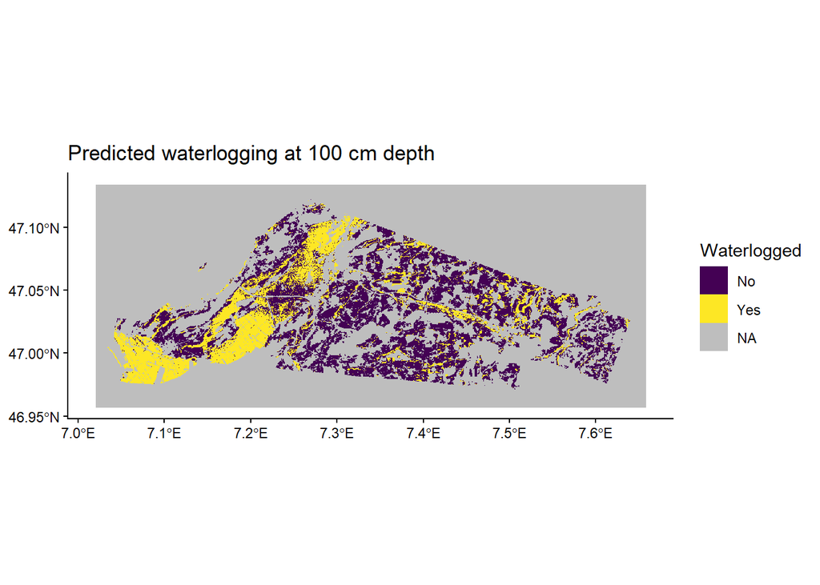

```r
levels(raster_pred_bor) <- data.frame(ID = c(0, 1), label = c("No", "Yes"))

ggplot() +
  geom_spatraster(data = raster_pred_bor) +
  scale_fill_viridis_d(
    na.value = "grey",
    option = "viridis",
    name = "Waterlogged",
    labels = c("No","Yes", "NA")
  ) +
  theme_classic() +
  labs(title = "Predicted waterlogging at 100 cm depth")
```

### 8.4 Save GeoTIFF

```r
terra::writeRaster(
   raster_pred_bor,
  here::here("data", "raster_pred_bor.tif"),
   datatype = "FLT4S",
   filetype = "GTiff",
   overwrite = TRUE
)
```

## 9 Hyperparameter tuning - Exercise 3

### 9.1 Cross-validation preparation

```r
# Select predictors
x_train <- as.data.frame(df_train[, predictors_selected])
x_test  <- as.data.frame(df_test[, predictors_selected])

# Recode target so that the positive class is alphabetically first
# (caret requirement for ROC / AUC calculation)
y_train <- factor(
  ifelse(df_train[[target]] == "1", "A_Yes", "B_No")
)

y_test <- factor(
  ifelse(df_test[[target]] == "1", "A_Yes", "B_No")
)
```

### 9.2 Grid tuning

While the default “minimum node size” for classification is 1, I restricted the tuning grid to values of 2 and above to ensure generaliseability and reduce the risk of the individual trees overfitting to noise in the training set.

```r
set.seed(12)
rf_grid <- expand.grid(
  mtry = c(2, 5, 10),
  splitrule = "gini",
  min.node.size = c(2,5,10)
)

ctrl <- trainControl(
  method = "cv",
  number = 5,
  classProbs = TRUE,
  summaryFunction = twoClassSummary
)
```

### 9.3 Model tuning and tuning results

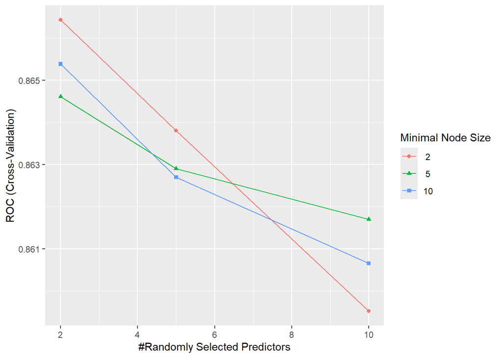

```r
set.seed(12)
rf_bor_cv <- caret::train(
  x = x_train,
  y = y_train,
  method = "ranger",
  tuneGrid = rf_grid,
  trControl = ctrl,
  importance = "permutation",
   metric = "ROC"
)

ggplot(rf_bor_cv)
```

```r
hyperparameters<-rf_bor_cv$bestTune
hyperparameters
```

```
##   mtry splitrule min.node.size
## 1    2      gini             2
```

### 9.3 Validation performance

Evaluation on the test set.

```r
# Predict class probabilities on validation data
prob_test <- predict(rf_bor_cv, newdata = x_test, type = "prob")
```

ROC curve

```r
roc_test <- roc(y_test, prob_test[, "A_Yes"])
best_threshold_df<- coords(roc_test, "best", ret = "threshold")
best_threshold<-best_threshold_df$threshold

# Convert probabilities to classes using optimal threshold for avoiding arbitrary 0.5 cutoff.
#If the predicted probability higher this threshold, classified waterlogged, else not waterlogged
pred_test <- ifelse(prob_test[, "A_Yes"] > best_threshold, "A_Yes", "B_No")

pred_test <- factor(pred_test, levels = levels(y_test))

# Confusion matrix
cm_test<-confusionMatrix(factor(pred_test, levels = c("A_Yes", "B_No")), y_test)

cm_test
```

```
## Confusion Matrix and Statistics
##
##           Reference
## Prediction A_Yes B_No
##      A_Yes    50   25
##      B_No     20  105
##
##                Accuracy : 0.775
##                  95% CI : (0.7108, 0.8309)
##     No Information Rate : 0.65
##     P-Value [Acc > NIR] : 8.759e-05
##
##                   Kappa : 0.5135
##
##  Mcnemar's Test P-Value : 0.551
##
##             Sensitivity : 0.7143
##             Specificity : 0.8077
##          Pos Pred Value : 0.6667
##          Neg Pred Value : 0.8400
##              Prevalence : 0.3500
##          Detection Rate : 0.2500
##    Detection Prevalence : 0.3750
##       Balanced Accuracy : 0.7610
##
##        'Positive' Class : A_Yes
##
```

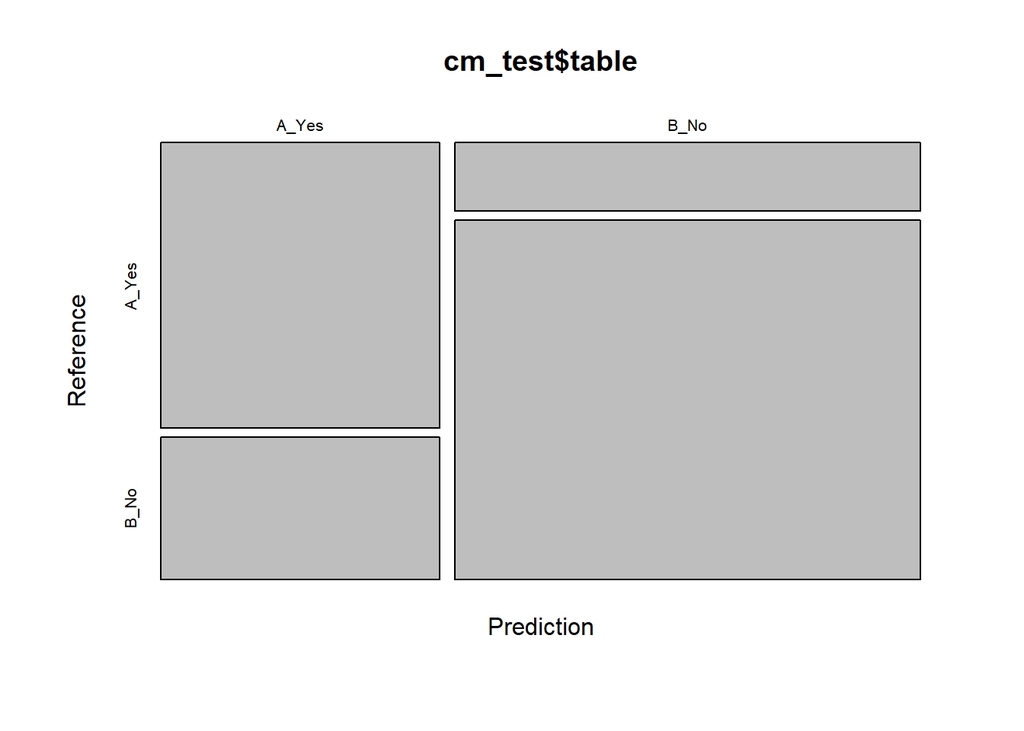

```r
mosaicplot(cm_test$table)
```

## Question 3

Does the model with adjusted hyperparameters perform better?

Comparing the two models, the Untuned Model performs better across all RF-default metrics. It is ~ 1.5% more accurate. That the 95% CIs overlap (72.7%–84.4% for the untuned model and 71.1%-83.1% for the tuned model) tells us that though the untuned model is better, both models perform similarly well and are stable and reliable. For the final mapping of waterlogging at 100 cm depth, the default settings provided the most reliable results and though this model should be used for spatial upscaling.

## 10. Random Forest probability model - Exercise 4

Train Probability Model with adjusted hyperparameters:

```r
rf_prob_adj <- ranger(
 y = df_train[, target], # target variable
  x = df_train[, predictors_selected],
  seed = 42,
  num.threads = parallel::detectCores() - 1,
  probability = TRUE,
  mtry = hyperparameters$mtry ,
  splitrule = "gini",
  min.node.size = hyperparameters$min.node.size,
)

# quick report and performance of trained model object
rf_prob_adj
```

```
## Ranger result
##
## Call:
##  ranger(y = df_train[, target], x = df_train[, predictors_selected],      seed = 42, num.threads = parallel::detectCores() - 1, probability = TRUE,      mtry = hyperparameters$mtry, splitrule = "gini", min.node.size = hyperparameters$min.node.size,      )
##
## Type:                             Probability estimation
## Number of trees:                  500
## Sample size:                      605
## Number of independent variables:  37
## Mtry:                             2
## Target node size:                 2
## Variable importance mode:         none
## Splitrule:                        gini
## OOB prediction error (Brier s.):  0.1430735
```

```r
probs_1_adj <- rf_prob_adj$predictions[, "1"]
```

### 10.2 ROC and AUC analysis

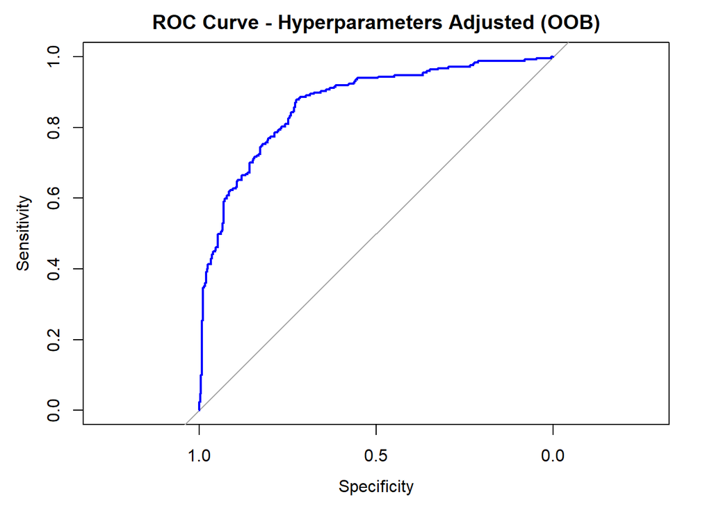

```r
roc_obj_adj <- roc(
  response = df_train[, target],
  predictor = probs_1_adj,
  levels = c("0", "1"),
  direction = "<"
)

# Plot ROC curve
plot(roc_obj_adj, col = "blue", lwd = 2, main = "ROC Curve - Hyperparameters Adjusted (OOB)")
```

```r
# AUC
auc(roc_obj_adj)
```

```
## Area under the curve: 0.868
```

Brier Score

```r
rf_prob_adj$prediction.error
```

```
## [1] 0.1430735
```

Interpretation Roc/ AUC The hyperparameter tuned probability model performs well above random and good with an AUC of 0.868. In soil modeling, an AUC above 0.80 is generally considered a high-quality result. The models Brier Score of 0.143 is well below the 0.25 (model with no predictive power), which confirms its reliability. These values indicate that the model is not simply guessing categories, but rather provides informative probability estimates for waterlogging at 100 cm depth.

## Question 4

Consider you inform an infrastructure construction project where waterlogged soils severely jeopardize the stability of the building.(1) Then, consider you inform a project where waterlogged soils are unwanted, but not critical. (2) In both cases, your prediction map of a binary classification is used as a basis and the binary classification is derived from the probabilistic prediction.

### 4.1

How would you chose the threshold in each case? Would you chose the same threshold in both cases? If not, explain why.

I would choose the threshold for the cases based on the relative costs/risks of the error types false positive / false negative. For the “safety critical building site” (case 1) I would choose a lower threshold to avoid false negatives more strictly. For non-critical cases I would choose a higher threshold (to avoid unneccessary and costly intervention). There are algorithms that one can use to estimate appropriate thresholds like the Bayes Decision Theory (BDT) on which I would base this decision.

### 4.2

Can you think of an analogy of a similarly-natured problem in another realm?

A similarly natured problem could be the screening for a severe or contageant disease, that needs immediate treatment, where the cost of a false negative (missing a diseased person) would be very big. Whereas for the screening for a non severe and less contageant elective issue, I would set the threshold higher to avoid false positives and unnecessary invasive follow-up.